# Homework5

```r
library(MPV)
library(car)
```

## Question 1

1.The chemical data is available as table.b5 in MPV package. We read that first. Then fit a MLR model by regressing CO2 product (y) on total solvent (x6) and hydrogen consumption (x7). The equation of the fitted regression line is given by $\hat{y} = 2.5265 + 0.0185 x6 + 2.1857 x7$.

```r
data("table.b5")
dat=table.b5
View(dat)
dat <- dat[,c(1,7,8)]
## Fit MLR model
mlr <- lm(y ~ x6+x7 , data=dat)
summary(mlr)
```

```
##
## Call:
## lm(formula = y ~ x6 + x7, data = dat)
##
## Residuals:
##      Min       1Q   Median       3Q      Max
## -23.2035  -4.3713   0.2513   4.9339  21.9682
##
## Coefficients:
##             Estimate Std. Error t value Pr(>|t|)
## (Intercept) 2.526460   3.610055   0.700   0.4908
## x6          0.018522   0.002747   6.742 5.66e-07 ***
## x7          2.185753   0.972696   2.247   0.0341 *
## ---
## Signif. codes:  0 '***' 0.001 '**' 0.01 '*' 0.05 '.' 0.1 ' ' 1
##
## Residual standard error: 9.924 on 24 degrees of freedom
## Multiple R-squared:  0.6996, Adjusted R-squared:  0.6746
## F-statistic: 27.95 on 2 and 24 DF,  p-value: 5.391e-07
```

2.The following code can be used to find leverage, outlier and influential points.

```r
k = 2
n = 27

hatvalues(mlr) #High leverage if hatvalue > 2*(k+1)/n
```

```
##          1          2          3          4          5          6          7
## 0.16021319 0.06000041 0.06152532 0.08736743 0.11459396 0.05242107 0.04658937
##          8          9         10         11         12         13         14
## 0.10539751 0.07921440 0.19083767 0.05769269 0.05782157 0.08814614 0.11413649
##         15         16         17         18         19         20         21
## 0.03970389 0.06252694 0.20915302 0.06184129 0.49860288 0.08695744 0.05577443
##         22         23         24         25         26         27
## 0.07065008 0.07741509 0.14535595 0.03901516 0.20065073 0.17639589
```

```r
which(hatvalues(mlr) > (2*(k+1)/n)) # Obs 19 is flagged
```

```
## 19
## 19
```

```r
rstandard(mlr) #outlier if abs(rstandard) > 3
```

```
##            1            2            3            4            5            6
## -1.242730211  0.026114100 -0.361884795  0.007472475  0.313489250  0.578835801
##            7            8            9           10           11           12
##  0.159291238 -1.300230469  0.497208832  0.574954706  0.911158912  0.603695055
##           13           14           15           16           17           18
## -0.137669734  0.279833882  1.868046284  0.046138522 -2.629086497  1.412253756
##           19           20           21           22           23           24
## -1.195451210 -0.278972143 -0.330534921 -0.253448404 -0.583825569 -0.573679776
##           25           26           27
## -1.364813653  2.475841379  0.071671130
```

```r
which(abs(rstandard(mlr)) > 3) # No observation is flagged
```

```
## named integer(0)
```

```r
rstudent(mlr) #outlier if abs(rstudent) > 3
```

```
##            1            2            3            4            5            6
## -1.257703395  0.025564631 -0.355235846  0.007315151  0.307518999  0.570645655
##            7            8            9           10           11           12
##  0.156019859 -1.320201752  0.489266520  0.566765855  0.907814263  0.595523165
##           13           14           15           16           17           18
## -0.134824346  0.274389987  1.978173833  0.045169079 -3.050172439  1.443812003
##           19           20           21           22           23           24
## -1.206761289 -0.273542259 -0.324314530 -0.248444754 -0.575635383 -0.565491589
##           25           26           27
## -1.391153687  2.808807095  0.070169605
```

```r
which(abs(rstudent(mlr)) > 3) # Observation 17 is flagged
```

```
## 17
## 17
```

```r
dffits(mlr) #influential if abs(dffits) > 2*sqrt((k+2)/(n-k-2))
```

```
##            1            2            3            4            5            6
## -0.549342039  0.006458814 -0.090956232  0.002263342  0.110632204  0.134218310
##            7            8            9           10           11           12
##  0.034489215 -0.453148388  0.143505419  0.275244022  0.224626561  0.147528867
##           13           14           15           16           17           18
## -0.041918655  0.098491129  0.402233636  0.011665287 -1.568592877  0.370690756
##           19           20           21           22           23           24
## -1.203394001 -0.084417462 -0.078821753 -0.068500940 -0.166746646 -0.233211480
##           25           26           27
## -0.280306746  1.407258860  0.032473867
```

```r
which(abs(dffits(mlr)) > (2*sqrt((k+2)/(n-k-2)))) # Obs 17 19 26  are flagged
```

```
## 17 19 26
## 17 19 26
```

```r
cooks.distance(mlr) #influential if d > 1
```

```
##            1            2            3            4            5            6
## 9.821135e-02 1.450960e-05 2.861876e-03 1.781810e-06 4.239780e-03 6.178457e-03
##            7            8            9           10           11           12
## 4.133038e-04 6.639260e-02 7.089278e-03 2.598810e-02 1.694319e-02 7.455395e-03
##           13           14           15           16           17           18
## 6.107082e-04 3.363079e-03 4.809300e-02 4.732760e-05 6.093407e-01 4.382344e-02
##           19           20           21           22           23           24
## 4.737131e-01 2.470678e-03 2.151160e-03 1.627763e-03 9.533760e-03 1.865801e-02
##           25           26           27
## 2.520823e-02 5.128951e-01 3.667222e-04
```

```r
which(cooks.distance(mlr) > 1) # No observation is flagged
```

```
## named integer(0)
```

```r
covratio(mlr) #influential if covratio > 1 + 3*(k+1)/n OR covratio < 1 - 3*(k+1)/n
```

```
##         1         2         3         4         5         6         7         8
## 1.1082116 1.2086082 1.1909643 1.2449480 1.2675401 1.1495234 1.1879333 1.0201173
##         9        10        11        12        13        14        15        16
## 1.1961937 1.3469270 1.0849012 1.1518093 1.2430702 1.2700635 0.7384718 1.2116463
##        17        18        19        20        21        22        23        24
## 0.5185498 0.9335471 1.8848686 1.2323312 1.1869431 1.2127718 1.1797974 1.2754841
##        25        26        27
## 0.9278397 0.5867713 1.3786462
```

```r
which(covratio(mlr) > (1 + 3*(k+1)/n)) # Obs 10 19 27   are flagged
```

```
## 10 19 27
## 10 19 27
```

```r
which(covratio(mlr) < (1 - 3*(k+1)/n)) # Obs 17 26 are flagged
```

```
## 17 26
## 17 26
```

The above output suggests that (a) observation 19 is a high leverage point, (b) observation 17 is a outlier, (c) Observations 10, 17, 19, 26, 27 are influential points. The following code marks these points in the scatter plot. From the plots it is clear that (a) observation 19 has an extreme x7 value, (b) observation has an unusual y value when plotted against x6, (c) observations 10, 26, 27 are quite unusual in both response and regressor variable values when y is plotted against x7.

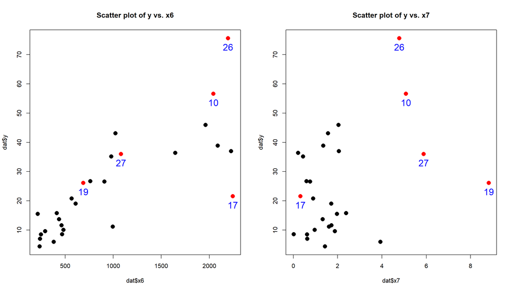

```r
cols <- character(nrow(dat))

cols[] <- "black"
pts <- c(10, 17, 19, 26, 27)
for (i in 1:length(pts)){
 cols[dat$y == dat[pts[i],1]] <- "red"
}

par(mfrow = c(1, 2))
plot(dat$x6, dat$y, main = "Scatter plot of y vs. x6", col=cols, pch=16, cex=1.5)
for (i in 1:length(pts)){
 text(dat$x6[pts[i]], (dat$y[pts[i]]-3), pts[i], cex=1.5, col = "blue")
}
plot(dat$x7, dat$y, main = "Scatter plot of y vs. x7", col=cols, pch=16, cex=1.5)
for (i in 1:length(pts)){
 text(dat$x7[pts[i]], (dat$y[pts[i]]-3), pts[i], cex=1.5, col = "blue")
}
```

Now let us take a look at the residual plot for verifying 0 mean and constant variance assumption and the normal q-q plot. The following code creates those plots and marks the flagged observations in red color. We note that, the magnitude of residual for observations 17 and 26 are noticeably high and these points are far away from the q-q line.

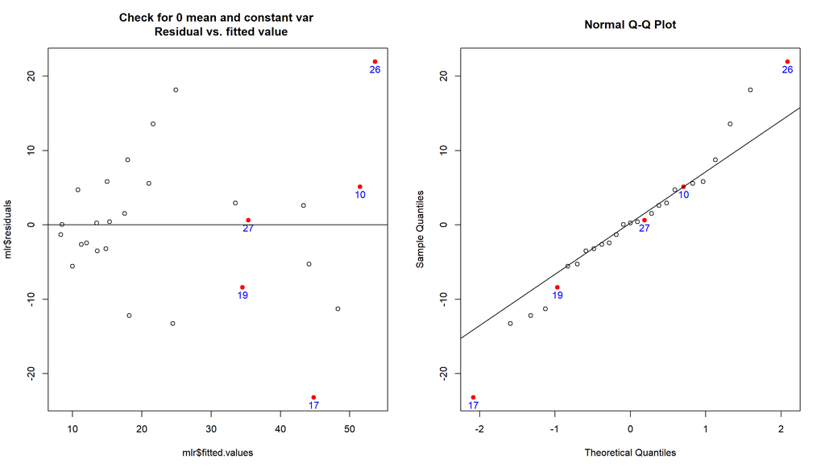

```r
par(mfrow = c(1, 2))
## Check for zero mean and constant variance of random error
plot(mlr$fitted.values, mlr$residuals,
     main = "Check for 0 mean and constant var \n  Residual vs. fitted value")
for (i in 1:length(pts)){
 points(mlr$fitted.values[pts[i]], mlr$residuals[pts[i]], col = "red", pch = 19)
 text(mlr$fitted.values[pts[i]], (mlr$residuals[pts[i]]-1), pts[i], col = "blue")
}
abline(h=0)

## Check for normality of random error
qqnorm(mlr$residuals)
a=qqnorm(mlr$residuals, plot.it = FALSE)
for (i in 1:length(pts)){
 points(a$x[pts[i]], a$y[pts[i]], col = "red", pch = 19)
 text(a$x[pts[i]], (a$y[pts[i]]-1), pts[i], col = "blue")
}
qqline(mlr$residuals)
```

Let us see how the regression line behaves if we remove these two points from our analysis. The following code fits a MLR model after removing these points from the data set.

```r
dat2 <- dat[-c(17, 26),]
## Fit MLR model
mlr2 <- lm(y ~ x6+x7 , data=dat2)
summary(mlr2)
```

```
##
## Call:
## lm(formula = y ~ x6 + x7, data = dat2)
##
## Residuals:
##     Min      1Q  Median      3Q     Max
## -13.842  -4.362  -0.211   4.613  17.539
##
## Coefficients:
##             Estimate Std. Error t value Pr(>|t|)
## (Intercept) 4.105952   2.833901   1.449    0.161
## x6          0.019243   0.002403   8.007 5.82e-08 ***
## x7          1.110087   0.771929   1.438    0.164
## ---
## Signif. codes:  0 '***' 0.001 '**' 0.01 '*' 0.05 '.' 0.1 ' ' 1
##
## Residual standard error: 7.487 on 22 degrees of freedom
## Multiple R-squared:  0.7619, Adjusted R-squared:  0.7403
## F-statistic:  35.2 on 2 and 22 DF,  p-value: 1.394e-07
```

We note that the estimated regression coefficients of the new model are noticeably different from the previous one. The associate standard errors are also smaller. This is not surprising because both observations 17 and 26 are identified as influential point by the covratio statistic which provides insight about the precision of estimation. We note that the residual standard error is smaller for the new model which is a good thing because smaller MSE (residual standard error square) results in narrower prediction and confidence intervals. Finally we may create the residual plot and q-q plot for the new model as below. We note that the residual plot has improved and the normal q-q plot suggests that error terms follow normal distribution.

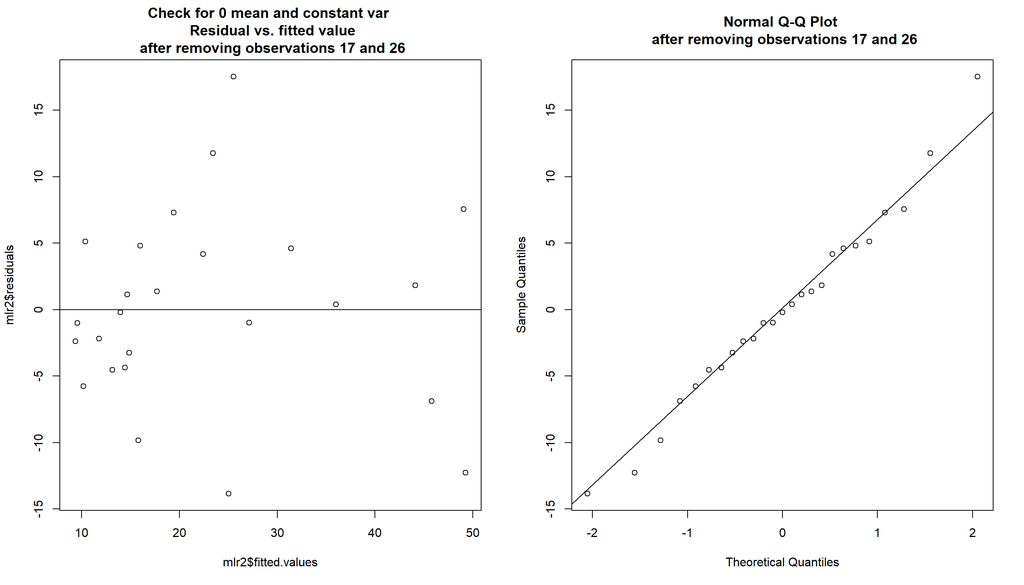

```r
par(mfrow = c(1, 2))
## Check for zero mean and constant variance of random error
plot(mlr2$fitted.values, mlr2$residuals,
     main = "Check for 0 mean and constant var \n  Residual vs. fitted value \n after removing observations 17 and 26")
abline(h=0)

## Check for normality of random error
qqnorm(mlr2$residuals, main = "Normal Q-Q Plot \n after removing observations 17 and 26")
qqline(mlr2$residuals)
```

We conclude that observations 17 and 26 has a noticeable impact on the regression model where y is regressed on x6 and X7. Whether we can safely remove them or not from the analysis depends on the context of the particular business problem.